# Análise Multivariada do conjunto de dados Wine

Author

Gabriel Sanábio Mazzetti Affonso

Published

July 22, 2026

# Introdução

Neste relatório realizaremos uma análise multivariada aplicada ao conjunto de dados **Wine**, extraído do *UCI Machine Learning Repository* (Lichman 2013). O banco de dados é composto por análises químicas de 178 amostras de vinhos cultivados em uma mesma região da Itália. A variável resposta de interesse consiste na origem do vinho, que se divide em três cultivares (castas) distintas, estabelecendo três classes a serem avaliadas. Para cada amostra, foram aferidas 13 variáveis contínuas, que quantificam características como teor alcoólico, composição fenólica, intensidade de cor e alcalinidade. As técnicas que aplicaremos são fundamentadas na literatura indicada na bibliografia da disciplina de Análise Multivariada (Johnson and Wichern 2007):

- Análise de Componentes Principais (PCA): Conduzida por meio da decomposição espectral manual da matriz de correlação, visando a redução de dimensionalidade.
- Análise Fatorial (FA): Ajustada via máxima verossimilhança para identificar construtos latentes inerentes à composição do vinho.
- Análise Discriminante (LDA e QDA): Modelada sob a ótica de um problema de controle de qualidade, objetivando classificar e certificar a procedência (cultivar) de lotes desconhecidos a partir das medições químicas.

## Análise Exploratória dos Dados

Antes da aplicação dos métodos, precisamos analisar a base de dados e suas características. Para facilitar a visualização, renomeei as colunas de acordo com seus nomes técnicos, presentes no repositório de onde vieram os dados.

**Exibir Código**

```r
dados <- read.table("D:/multivariada/trabalho_final/wine.dat", header = TRUE)

nomes_variaveis <- c("Classe", "Alcohol", "Malic_acid", "Ash", "Alcalinity_ash",
                     "Magnesium", "Total_phenols", "Flavanoids", "Nonflavanoid_phenols",
                     "Proanthocyanins", "Color_intensity", "Hue", "OD280_OD315", "Proline")
colnames(dados) <- nomes_variaveis

dados$Classe <- factor(dados$Classe, labels = c("Cultivar 1", "Cultivar 2", "Cultivar 3"))

X <- dados[, -1]
classe <- dados$Classe

summary(X)
```

```
    Alcohol        Malic_acid         Ash        Alcalinity_ash
 Min.   :11.03   Min.   :0.740   Min.   :1.360   Min.   :10.60
 1st Qu.:12.36   1st Qu.:1.603   1st Qu.:2.210   1st Qu.:17.20
 Median :13.05   Median :1.865   Median :2.360   Median :19.50
 Mean   :13.00   Mean   :2.336   Mean   :2.367   Mean   :19.49
 3rd Qu.:13.68   3rd Qu.:3.083   3rd Qu.:2.558   3rd Qu.:21.50
 Max.   :14.83   Max.   :5.800   Max.   :3.230   Max.   :30.00
   Magnesium      Total_phenols     Flavanoids    Nonflavanoid_phenols
 Min.   : 70.00   Min.   :0.980   Min.   :0.340   Min.   :0.1300
 1st Qu.: 88.00   1st Qu.:1.742   1st Qu.:1.205   1st Qu.:0.2700
 Median : 98.00   Median :2.355   Median :2.135   Median :0.3400
 Mean   : 99.74   Mean   :2.295   Mean   :2.029   Mean   :0.3619
 3rd Qu.:107.00   3rd Qu.:2.800   3rd Qu.:2.875   3rd Qu.:0.4375
 Max.   :162.00   Max.   :3.880   Max.   :5.080   Max.   :0.6600
 Proanthocyanins Color_intensity       Hue          OD280_OD315
 Min.   :0.410   Min.   : 1.280   Min.   :0.4800   Min.   :1.270
 1st Qu.:1.250   1st Qu.: 3.220   1st Qu.:0.7825   1st Qu.:1.938
 Median :1.555   Median : 4.690   Median :0.9650   Median :2.780
 Mean   :1.591   Mean   : 5.058   Mean   :0.9574   Mean   :2.612
 3rd Qu.:1.950   3rd Qu.: 6.200   3rd Qu.:1.1200   3rd Qu.:3.170
 Max.   :3.580   Max.   :13.000   Max.   :1.7100   Max.   :4.000
    Proline
 Min.   : 278.0
 1st Qu.: 500.5
 Median : 673.5
 Mean   : 746.9
 3rd Qu.: 985.0
 Max.   :1680.0
```

Dado que as escalas das variáveis são bastante heterogêneas, a avaliação da estrutura de dependência linear deve ser feita através da matriz de correlação (que padroniza as variâncias).

**Exibir Código**

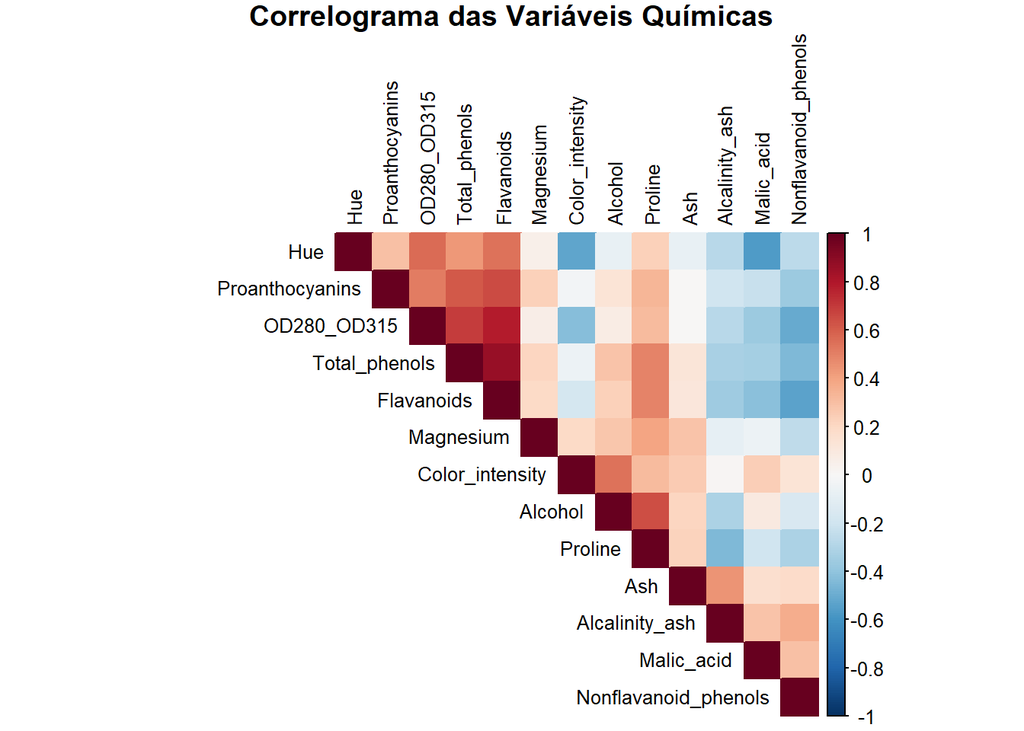

```r
R <- cor(X)

cores_divergente <- brewer.pal(n = 11, name = "RdBu")

corrplot(
  R,
  method = "color",
  type = "upper",
  order = "hclust",
  col = colorRampPalette(rev(cores_divergente))(200),
  tl.col = "black",
  tl.cex = 0.8,
  addCoef.col = NULL,
  title = "Correlograma das Variáveis Químicas",
  mar = c(0,0,1,0)
)
```

A visualização do correlograma revela que existem correlações fortes entre algumas variáveis (por exemplo, entre Flavanoids e Total_phenols, e entre Flavanoids e OD280_OD315). Este padrão de interdependência é um indício de redundância de informação e reforça a pertinência de técnicas de redução de dimensionalidade como a PCA e a Análise Fatorial (Hair et al. 2009).

# Análise de Componentes Principais

## Proporção da Variância Explicada

A Análise de Componentes Principais tem como objetivo rotacionar o sistema de coordenadas originais de modo a encontrar combinações lineares ortogonais que maximizem a variância explicada (Johnson and Wichern 2007). Primeiramente, iremos obter a matriz de correlações R, e dela iremos extrair os autovalores e autovetores. Por fim, vamos construir os escores $Y = ZE$, onde $E$ é a matriz ortogonal cujas colunas são os autovetores.

**Exibir Código**

```r
# matriz Z
Z <- scale(X, center = TRUE, scale = TRUE)

#  matriz de correlação
R_mat <- cor(X)

# decomposição espectral
eig <- eigen(R_mat, symmetric = TRUE)
autovalores <- eig$values
autovetores <- eig$vectors

rownames(autovetores) <- colnames(X)
colnames(autovetores) <- paste0("CP", 1:ncol(X))

# escores
escores <- Z %*% autovetores
colnames(escores) <- paste0("CP", 1:ncol(X))

# proporção de variância explicada

prop_var <- autovalores / sum(autovalores)
prop_acum <- cumsum(prop_var)

tabela_var <- data.frame(
  Componente = paste0("CP", 1:length(autovalores)),
  Autovalor = autovalores,
  Prop_Variancia = prop_var,
  Prop_Acumulada = prop_acum
)

kable(head(tabela_var, 5), digits = 4,
      caption = "Resumo dos 5 primeiros autovalores e variâncias explicadas.")
```

Resumo dos 5 primeiros autovalores e variâncias explicadas.

| Componente | Autovalor | Prop_Variancia | Prop_Acumulada |
| --- | --- | --- | --- |
| CP1 | 4.7059 | 0.3620 | 0.3620 |
| CP2 | 2.4970 | 0.1921 | 0.5541 |
| CP3 | 1.4461 | 0.1112 | 0.6653 |
| CP4 | 0.9190 | 0.0707 | 0.7360 |
| CP5 | 0.8532 | 0.0656 | 0.8016 |

Podemos observar que apenas as duas primeiras componentes concentram aproximadamente 55% da variabilidade total dos dados, enquanto as três primeiras representam cerca de 67%. Esse resultado evidencia que grande parte da informação originalmente presente nas treze variáveis pode ser resumida por um número bastante reduzido de dimensões, justificando o uso da PCA como técnica de redução de dimensionalidade.

## Scree Plot

Vamos utilizar o Scree Plot para ilustrar o decaimento dos autovalores:

**Exibir Código**

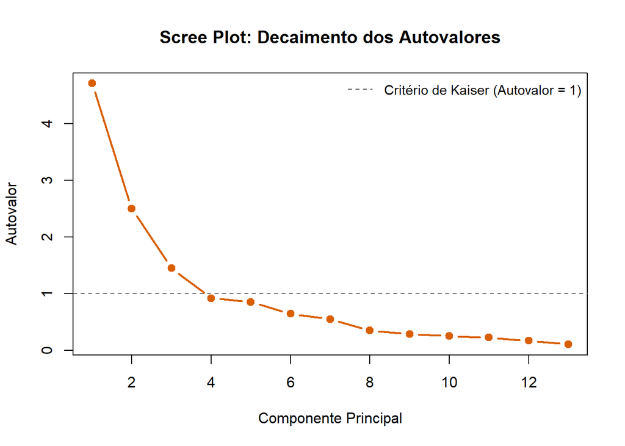

```r
cores_categorica <- brewer.pal(n = 8, name = "Dark2")
cores <- cores_categorica[c(1, 3, 5)]

plot(autovalores, type = "b", pch = 19, lwd = 2, col = cores_categorica[2],
     xlab = "Componente Principal", ylab = "Autovalor",
     main = "Scree Plot: Decaimento dos Autovalores")
abline(h = 1, lty = 2, col = cores_categorica[8])  # Critério de Kaiser
legend("topright", legend = "Critério de Kaiser (Autovalor = 1)",
       lty = 2, col = cores_categorica[8], bty = "n", cex = 0.9)
```

De acordo com o Critério de Kaiser (retenção de componentes com $\lambda > 1$), bem como pela análise da curva do Scree Plot, constatamos que um reduzido número de componentes capta grande proporção da variabilidade inerente ao sistema multivariado. As três primeiras componentes principais (CP1, CP2 e CP3) representam em conjunto aproximadamente 67% da variabilidade total.

## Loadings

**Exibir Código**

```r
loadings_123 <- round(autovetores[, 1:3], 3)
knitr::kable(loadings_123, caption = "Cargas (autovetores) das três primeiras componentes principais")
```

Cargas (autovetores) das três primeiras componentes principais

|  | CP1 | CP2 | CP3 |
| --- | --- | --- | --- |
| Alcohol | -0.144 | -0.484 | -0.207 |
| Malic_acid | 0.245 | -0.225 | 0.089 |
| Ash | 0.002 | -0.316 | 0.626 |
| Alcalinity_ash | 0.239 | 0.011 | 0.612 |
| Magnesium | -0.142 | -0.300 | 0.131 |
| Total_phenols | -0.395 | -0.065 | 0.146 |
| Flavanoids | -0.423 | 0.003 | 0.151 |
| Nonflavanoid_phenols | 0.299 | -0.029 | 0.170 |
| Proanthocyanins | -0.313 | -0.039 | 0.149 |
| Color_intensity | 0.089 | -0.530 | -0.137 |
| Hue | -0.297 | 0.279 | 0.085 |
| OD280_OD315 | -0.376 | 0.164 | 0.166 |
| Proline | -0.287 | -0.365 | -0.127 |

A CP1 apresenta cargas relevantes e de mesmo sinal em variáveis como Flavanoids, Total_phenols e OD280_OD315, podendo ser interpretada como um eixo geral relacionado ao teor fenólico do vinho. A CP2 contrasta principalmente Color_intensity e Alcohol com Hue, sendo associada a um eixo de intensidade de cor e estrutura. Já a CP3 (que eleva a variância explicada a 67%) geralmente destaca variáveis que não foram bem representadas nas duas primeiras, como Ash (Cinzas) e Alcalinity_ash (Alcalinidade das cinzas), configurando um eixo relacionado à composição mineral do vinho.

## Projeção 3D dos Escores

Para incorporar a parcela de variância explicada pela terceira componente, projetamos as amostras no espaço tridimensional formado por CP1, CP2 e CP3.

**Exibir Código**

```r
library(plotly)

cores_seguras <- c("#E69F00", "#56B4E9", "#CC79A7")

plot_ly(
  x = escores[, 1],
  y = escores[, 2],
  z = escores[, 3],
  color = classe,
  colors = cores_seguras,
  type = "scatter3d",
  mode = "markers",
  marker = list(
    size = 6,
    opacity = 0.9,
    line = list(width = 0.3, color = "black")
  )
) %>%
  layout(
    title = "Projeção 3D (CP1 x CP2 x CP3)",
    autosize = TRUE,
    scene = list(
      xaxis = list(title = sprintf("CP1 (%.1f%%)", prop_var[1] * 100)),
      yaxis = list(title = sprintf("CP2 (%.1f%%)", prop_var[2] * 100)),
      zaxis = list(title = sprintf("CP3 (%.1f%%)", prop_var[3] * 100)),
      camera = list(eye = list(x = 1.4, y = 1.4, z = 1.1))
    ),

    margin = list(l = 0, r = 0, b = 0, t = 40)
  )
```

[interactive chart not shown]

A visualização em três dimensões mostra de forma mais clara a separação entre as três cultivares. Enquanto os dois primeiros componentes principais (CP1 e CP2) já permitiam distinguir bem os grupos com base nas características químicas dos vinhos, a inclusão do terceiro componente (CP3) melhora ainda mais essa visualização, reduzindo a sobreposição entre as classes. Esse resultado indica que as variáveis químicas utilizadas conseguem representar bem as diferenças entre as cultivares, justificando o uso das técnicas de Análise Fatorial e de Análise Discriminante (LDA e QDA), que serão apresentadas nas próximas seções.

# Análise Fatorial

Diferentemente da PCA, a Análise Fatorial parte de um modelo estatístico explícito, no qual cada variável observada é escrita como combinação linear de um número menor de fatores comuns, não observáveis, mais um termo de erro específico (unicidade) (Hair et al. 2009). O modelo é expresso por:

$$X_j = \sum_{k=1}^{m} \ell_{jk} F_k + \varepsilon_j, \qquad j = 1, \dots, p$$

em que $\ell_{jk}$ são as cargas fatoriais, $F_k$ os fatores comuns e $\varepsilon_j$ a unicidade de cada variável. Utilizaremos a função `factanal`, que estima o modelo por máxima verossimilhança.

## Escolha do Número de Fatores

Para determinar a dimensão estrutural $m$, iteramos o ajuste do modelo de 1 a 6 fatores e avaliamos o teste de razão de verossimilhança.

**Exibir Código**

```r
resultados_fa <- list()

for (m in 1:6) {
  fit <- tryCatch(
    factanal(X, factors = m, rotation = "varimax"),
    error = function(e) NULL
  )
  if (!is.null(fit)) {
    resultados_fa[[m]] <- fit
  }
}

tabela_fa <- data.frame(
  Fatores = seq_along(resultados_fa),
  Estatistica_QuiQuadrado = sapply(resultados_fa, function(f) round(f$STATISTIC, 2)),
  GL = sapply(resultados_fa, function(f) f$dof),
  p_valor = sapply(resultados_fa, function(f) round(f$PVAL, 4))
)

knitr::kable(tabela_fa, caption = "Teste de adequação do número de fatores (H0: m fatores são suficientes)")
```

Teste de adequação do número de fatores (H0: m fatores são suficientes)

| Fatores | Estatistica_QuiQuadrado | GL | p_valor |
| --- | --- | --- | --- |
| 1 | 563.64 | 65 | 0.0000 |
| 2 | 279.68 | 53 | 0.0000 |
| 3 | 158.55 | 42 | 0.0000 |
| 4 | 76.92 | 32 | 0.0000 |
| 5 | 38.86 | 23 | 0.0206 |
| 6 | 17.16 | 15 | 0.3093 |

**Exibir Código**

```r
m_escolhido <- min(which(sapply(resultados_fa, function(f) f$PVAL) > 0.05))
fa_final <- resultados_fa[[m_escolhido]]
pval_escolhido <- round(fa_final$PVAL, 4)

cat("Número de fatores escolhido (m):", m_escolhido, "\n")
```

```
Número de fatores escolhido (m): 6
```

**Exibir Código**

```r
cat("P-valor associado:", pval_escolhido, "\n")
```

```
P-valor associado: 0.3093
```

## Cargas Fatoriais e Comunalidades

Para extrair as cargas, utilizaremos a rotação ortogonal Varimax, que busca maximizar a variância das cargas quadradas em cada fator, simplificando a interpretação.

**Exibir Código**

```r
cargas <- round(unclass(fa_final$loadings), 3)
knitr::kable(cargas, caption = "Cargas fatoriais após rotação Varimax")
```

Cargas fatoriais após rotação Varimax

|  | Factor1 | Factor2 | Factor3 | Factor4 | Factor5 | Factor6 |
| --- | --- | --- | --- | --- | --- | --- |
| Alcohol | 0.142 | 0.763 | 0.035 | 0.254 | 0.124 | 0.087 |
| Malic_acid | -0.245 | 0.002 | 0.129 | 0.095 | 0.793 | -0.024 |
| Ash | 0.053 | 0.177 | 0.967 | 0.059 | 0.063 | 0.138 |
| Alcalinity_ash | -0.233 | -0.463 | 0.541 | 0.094 | 0.193 | -0.023 |
| Magnesium | 0.148 | 0.196 | 0.114 | 0.061 | -0.020 | 0.958 |
| Total_phenols | 0.841 | 0.252 | 0.049 | -0.035 | -0.165 | 0.036 |
| Flavanoids | 0.907 | 0.221 | 0.050 | -0.131 | -0.233 | 0.017 |
| Nonflavanoid_phenols | -0.516 | -0.143 | 0.261 | 0.108 | 0.114 | -0.194 |
| Proanthocyanins | 0.697 | 0.055 | -0.055 | 0.060 | -0.071 | 0.129 |
| Color_intensity | -0.133 | 0.410 | 0.126 | 0.875 | 0.149 | 0.078 |
| Hue | 0.379 | 0.067 | -0.048 | -0.475 | -0.524 | 0.011 |
| OD280_OD315 | 0.750 | 0.097 | -0.013 | -0.385 | -0.177 | -0.044 |
| Proline | 0.322 | 0.769 | 0.053 | 0.052 | -0.155 | 0.191 |

**Exibir Código**

```r
# comunalidades
comunalidades <- round(1 - fa_final$uniquenesses, 3)
knitr::kable(
  data.frame(Variavel = names(comunalidades), Comunalidade = comunalidades),
  caption = "Comunalidades: proporção da variância de cada variável explicada pelos fatores comuns"
)
```

Comunalidades: proporção da variância de cada variável explicada pelos fatores comuns

|  | Variavel | Comunalidade |
| --- | --- | --- |
| Alcohol | Alcohol | 0.692 |
| Malic_acid | Malic_acid | 0.715 |
| Ash | Ash | 0.995 |
| Alcalinity_ash | Alcalinity_ash | 0.607 |
| Magnesium | Magnesium | 0.995 |
| Total_phenols | Total_phenols | 0.802 |
| Flavanoids | Flavanoids | 0.945 |
| Nonflavanoid_phenols | Nonflavanoid_phenols | 0.417 |
| Proanthocyanins | Proanthocyanins | 0.518 |
| Color_intensity | Color_intensity | 0.995 |
| Hue | Hue | 0.651 |
| OD280_OD315 | OD280_OD315 | 0.753 |
| Proline | Proline | 0.761 |

A análise das cargas fatoriais após a rotação Varimax permite identificar grupos de variáveis que representam diferentes características dos vinhos. O primeiro fator está relacionado aos compostos fenólicos, reunindo variáveis como flavonoides, fenóis totais, absorbância e proantocianidinas. O segundo fator está associado principalmente ao teor alcoólico e à prolina, refletindo características ligadas à composição da uva. O terceiro fator representa a composição mineral, sendo definido principalmente pelas cinzas e, em menor intensidade, pela alcalinidade. O quarto fator está ligado à aparência do vinho, relacionando a intensidade da cor e a tonalidade. Já o quinto e o sexto fatores representam, respectivamente, a acidez málica e a concentração de magnésio.

As comunalidades mostram quanto da variação de cada variável é explicada pelos seis fatores obtidos. De modo geral, os resultados indicam um bom ajuste do modelo, já que a maior parte das variáveis foi bem representada. Variáveis como cinzas, magnésio e intensidade de cor apresentaram valores muito altos, indicando que quase toda a sua variabilidade foi explicada pelos fatores. Por outro lado, os fenóis não flavonoides e as proantocianidinas tiveram as menores comunalidades, sugerindo que parte importante de sua variação não é explicada pelo modelo fatorial.

# Análise Discriminante

Nesta etapa, aplicaremos as técnicas de classificação. A proposta é simular uma situação semelhante à de uma vinícola ou de um órgão de fiscalização, em que uma amostra de vinho é recebida sem qualquer informação sobre sua origem. A partir apenas das características químicas da amostra, o objetivo é identificar corretamente a qual cultivar ela pertence.

Para isso, serão utilizadas duas técnicas de classificação supervisionada: a Análise Discriminante Linear (LDA) e a Análise Discriminante Quadrática (QDA) (Johnson and Wichern 2007). Ambas constroem regras de classificação com base nas informações das amostras já conhecidas. A principal diferença entre elas é que a LDA considera que as cultivares possuem a mesma estrutura de variabilidade, enquanto a QDA permite que cada grupo apresente uma estrutura de variabilidade própria.

## Ajuste dos Modelos e Coeficientes

Utilizaremos o pacote `MASS` para estimar as funções discriminantes.

**Exibir Código**

```r
library(MASS)

modelo_lda <- lda(Classe ~ ., data = dados)
modelo_qda <- qda(Classe ~ ., data = dados)

coef_lda <- round(modelo_lda$scaling, 3)
knitr::kable(coef_lda, caption = "Coeficientes das funções discriminantes lineares (LDA)")
```

Coeficientes das funções discriminantes lineares (LDA)

|  | LD1 | LD2 |
| --- | --- | --- |
| Alcohol | -0.403 | 0.872 |
| Malic_acid | 0.165 | 0.305 |
| Ash | -0.369 | 2.346 |
| Alcalinity_ash | 0.155 | -0.146 |
| Magnesium | -0.002 | 0.000 |
| Total_phenols | 0.618 | -0.032 |
| Flavanoids | -1.661 | -0.492 |
| Nonflavanoid_phenols | -1.496 | -1.631 |
| Proanthocyanins | 0.134 | -0.307 |
| Color_intensity | 0.355 | 0.253 |
| Hue | -0.818 | -1.516 |
| OD280_OD315 | -1.158 | 0.051 |
| Proline | -0.003 | 0.003 |

A análise dos coeficientes das funções discriminantes mostra quais variáveis químicas são mais importantes para diferenciar as cultivares. Na primeira função discriminante (LD1), as variáveis com maior influência são **Flavanoids**, **Nonflavanoid_phenols**, **OD280_OD315** e **Hue**, indicando que as características relacionadas aos compostos fenólicos e às propriedades de cor são as que mais contribuem para a separação dos grupos.

Na segunda função discriminante (LD2), a variável **Ash** apresenta a maior contribuição, seguida novamente por **Nonflavanoid_phenols** e **Hue**. Isso indica que o teor de cinzas, juntamente com algumas características químicas já observadas na primeira função, ajuda a diferenciar as cultivares que ainda apresentam alguma proximidade após a separação realizada pela LD1.

## Visualização no Espaço Discriminante (LDA)

Como a LDA projeta os dados em um novo espaço de dimensões reduzidas ($K-1$ dimensões, sendo $K$ o número de classes), podemos visualizar a separação máxima obtida.

**Exibir Código**

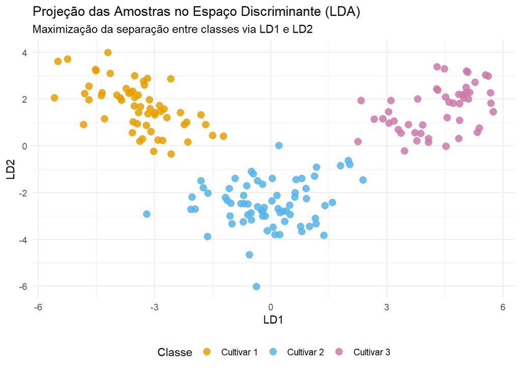

```r
# scores
pred_lda_treino <- predict(modelo_lda)
df_lda <- data.frame(pred_lda_treino$x, Classe = classe)

ggplot(df_lda, aes(x = LD1, y = LD2, color = Classe)) +
  geom_point(size = 3, alpha = 0.85) +
  scale_color_manual(values = cores_seguras) +
  labs(
    title = "Projeção das Amostras no Espaço Discriminante (LDA)",
    subtitle = "Maximização da separação entre classes via LD1 e LD2",
    x = "LD1",
    y = "LD2"
  ) +
  theme_minimal() +
  theme(legend.position = "bottom")
```

A separação entre as três cultivares no espaço discriminante é ainda mais nítida e bem definida do que a observada na PCA. Isso é o comportamento teoricamente esperado, uma vez que a LDA constrói os eixos ortogonais com o objetivo específico de maximizar a variância entre as classes em relação à variância dentro das classes, utilizando os rótulos conhecidos no processo de otimização.

## Avaliação da Taxa de Erro

Para estimar o desempenho do sistema de controle de qualidade em amostras inéditas (que o modelo não viu durante o treinamento), aplicaremos a validação cruzada leave-one-out. Cada observação é iterativamente removida, o modelo é reajustado com as 177 restantes e a amostra omitida é então classificada. A proporção de classificações incorretas fornece a taxa de erro aparente estimada por LOOCV.

**Exibir Código**

```r
# validação cruzada
modelo_lda_cv <- lda(Classe ~ ., data = dados, CV = TRUE)
modelo_qda_cv <- qda(Classe ~ ., data = dados, CV = TRUE)

# matrizes de confusão
matriz_confusao_lda <- table(Observado = classe, Predito = modelo_lda_cv$class)
matriz_confusao_qda <- table(Observado = classe, Predito = modelo_qda_cv$class)

# cálculo das métricas
erro_lda <- 1 - sum(diag(matriz_confusao_lda)) / sum(matriz_confusao_lda)
erro_qda <- 1 - sum(diag(matriz_confusao_qda)) / sum(matriz_confusao_qda)

knitr::kable(
  data.frame(
    Modelo = c("LDA", "QDA"),
    Erro_LOOCV = paste0(round(c(erro_lda, erro_qda) * 100, 2), "%"),
    Acuracia = paste0(round(c(1 - erro_lda, 1 - erro_qda) * 100, 2), "%")
  ),
  caption = "Desempenho de classificação estimado por validação cruzada (LOOCV)"
)
```

Desempenho de classificação estimado por validação cruzada (LOOCV)

| Modelo | Erro_LOOCV | Acuracia |
| --- | --- | --- |
| LDA | 1.12% | 98.88% |
| QDA | 0.56% | 99.44% |

Ambos os modelos apresentam taxas de erro extremamente baixas, o que indica que a composição química é altamente informativa para distinguir as três cultivares. Diante de desempenhos semelhantes, geralmente prefere-se a LDA por ser um modelo mais parcimonioso, estimando uma única matriz de covariância comum (ao invés de uma por classe), o que confere maior estabilidade analítica em amostras de tamanho moderado.

## Simulação de Novas Amostras

Para ilustrar a aplicação prática de certificação, vamos simular um lote de seis novas amostras de vinho. Elas foram geradas artificialmente a partir da distribuição normal multivariada de cada cultivar, utilizando o vetor de médias e a matriz de covariância comum estimada (S pooled).

**Exibir Código**

```r
set.seed(666)

# matriz de covariância "pooled"
n_classes <- table(classe)
S_pooled <- Reduce(`+`, lapply(levels(classe), function(cl) {
  Xc <- X[classe == cl, ]
  (n_classes[cl] - 1) * cov(Xc)
})) / (nrow(X) - length(levels(classe)))


gerar_amostra <- function(cl, n = 2) {
  mu <- colMeans(X[classe == cl, ])
  MASS::mvrnorm(n, mu = mu, Sigma = S_pooled)
}


novas_amostras <- as.data.frame(do.call(rbind, lapply(levels(classe), gerar_amostra)))
colnames(novas_amostras) <- colnames(X)
origem_real <- rep(levels(classe), each = 2)


pred_novas_lda <- predict(modelo_lda, newdata = novas_amostras)

tabela_novas <- data.frame(
  Amostra = paste0("Lote Simulado ", 1:nrow(novas_amostras)),
  Origem_Real = origem_real,
  Classificacao_LDA = pred_novas_lda$class,
  Prob_Posteriori_Max = apply(pred_novas_lda$posterior, 1, max)
)

knitr::kable(tabela_novas, digits = 4,
             caption = "Classificação e certificação das novas amostras simuladas (LDA)")
```

Classificação e certificação das novas amostras simuladas (LDA)

| Amostra | Origem_Real | Classificacao_LDA | Prob_Posteriori_Max |
| --- | --- | --- | --- |
| Lote Simulado 1 | Cultivar 1 | Cultivar 1 | 1.0000 |
| Lote Simulado 2 | Cultivar 1 | Cultivar 1 | 0.7718 |
| Lote Simulado 3 | Cultivar 2 | Cultivar 2 | 0.9995 |
| Lote Simulado 4 | Cultivar 2 | Cultivar 2 | 1.0000 |
| Lote Simulado 5 | Cultivar 3 | Cultivar 3 | 1.0000 |
| Lote Simulado 6 | Cultivar 3 | Cultivar 3 | 1.0000 |

Os resultados da simulação mostram que o modelo apresentou um excelente desempenho, classificando corretamente as seis amostras do lote desconhecido em suas respectivas cultivares. Além da classificação em si, a Análise Discriminante também fornece a probabilidade de cada amostra pertencer a cada grupo, permitindo avaliar o nível de confiança de cada previsão.

Cinco das seis amostras foram classificadas com probabilidades superiores a 99%, indicando alta confiança na decisão do modelo. Já a amostra **Lote Simulado 2** foi classificada na Cultivar 1 com uma probabilidade de 77,18%. Embora essa classificação esteja correta, o valor menor indica que essa amostra merece maior atenção. Em uma situação real, ela poderia ser encaminhada para uma nova análise antes da emissão da certificação, garantindo mais segurança no processo de controle de qualidade.

## Referências

Hair, Joseph F., William C. Black, Barry J. Babin, and Rolph E. Anderson. 2009. *Multivariate Data Analysis*. 7th ed. Prentice Hall.

Johnson, Richard A., and Dean W. Wichern. 2007. *Applied Multivariate Statistical Analysis*. 6th ed. Upper Saddle River, NJ: Prentice Hall.

Lichman, Moshe. 2013. “UCI Machine Learning Repository.” University of California, Irvine, School of Information; Computer Sciences. https://archive.ics.uci.edu/dataset/109/wine.